# DATA 605 - Homework #1

Julian Adames-Ng

2024-10-09

# 1. Geometric Transformation of Shapes Using Matrix Multiplication

## Context:

In computer graphics and data visualization, geometric transformations are fundamental. These transformations, such as translation, scaling, rotation, and reflection, can be applied to shapes to manipulate their appearance.

## Task:

Create a simple shape (like a square or triangle) using point plots in R. Implement R code to apply different transformations (scaling, rotation, reflection) to the shape by left multiplying a transformation matrix by each of the point vectors. Demonstrate these transformations through animated plots.

## Create a Shape:

Define a simple shape (e.g., a square) using a set of point coordinates. I made sure the aspect ratio was 1:1 using the “asp” parameter for the plot() function.

```r
rm(list = ls())

x=c(rep(0,500),seq(0.65,0.85,length.out=1000), seq(0.75,1,length.out=500), seq(0.5,0.75,length.out=500), seq(-1,0,length.out=500))
y=c(seq(-0.5,1,length.out=500),rep(0,1000), seq(1,-1,length.out=500), seq(-1,1,length.out=500), -0.5-sqrt(0.25-(seq(-1,1,length.out=500)-0.50)^2))
```

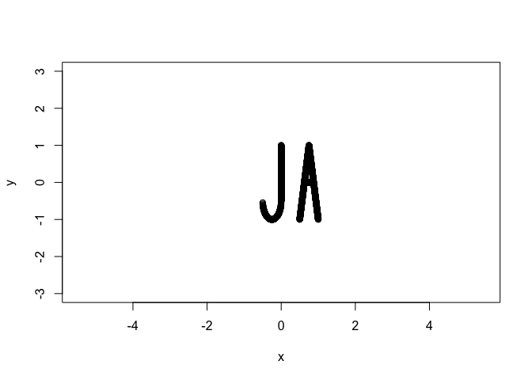

```r
z <- rbind(x, y)

# Create a plot
plot(y~x, xlim=c(-3,3), ylim=c(-3,3), asp = 1)
```

## Apply Transformations:

## Plot:

Display the original shape and its transformations in your compiled pdf. Demonstrate the effect of the transformations with fixed images.

Here I created a function called “leftMultiply” which performs matrix multiplication.

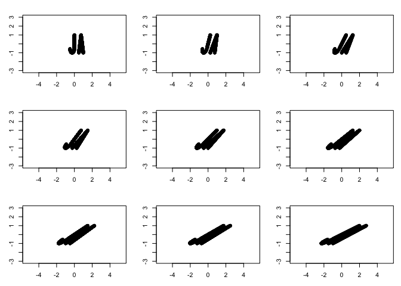

```r
leftMultiply  <- function(x,y){
   x %*% y
}

par(mfrow = c(3,3), mar = c(3,3,2,1))
for (i in seq(0,2,length.out=9)) {
  z_shear<-apply(z,2,function(x) leftMultiply(x,matrix(c(1,i,0,1),nrow=2,ncol=2)))
  plot(z_shear[2,]~z_shear[1,], xlim=c(-3,3), ylim=c(-3,3), col='black', asp = 1)
}
```

Enlarge or shrink the shape.

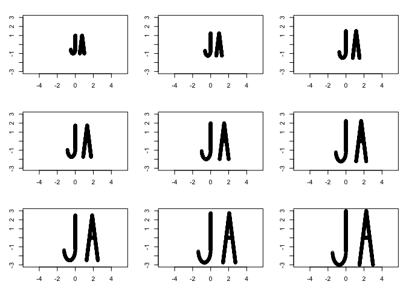

```r
par(mfrow = c(3,3), mar = c(3,3,2,1))
for (i in seq(1,3,length.out=9)) {
  z_scale<-apply(z,2,function(x) leftMultiply(x,matrix(c(i,0,0,i),nrow=2,ncol=2)))
   plot(z_scale[2,]~z_scale[1,], xlim=c(-3,3), ylim=c(-3,3), col='black', asp = 1)
}
```

Rotate the shape by a given angle.

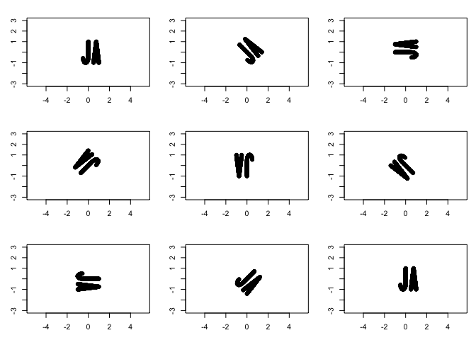

```r
par(mfrow = c(3,3), mar = c(3,3,2,1))
for (i in seq(0,pi*2,length.out=9)) {
  z_rotate<-apply(z,2,function(x) leftMultiply(x,matrix(c(cos(i),-sin(i),sin(i),cos(i)),nrow=2,ncol=2)))
   plot(z_rotate[2,]~z_rotate[1,], xlim=c(-3,3), ylim=c(-3,3), col = 'black', asp = 1)
}
```

Reflect the shape across an axis.

I rotated my initials just a bit so that the visualization shows a clear reflection process.

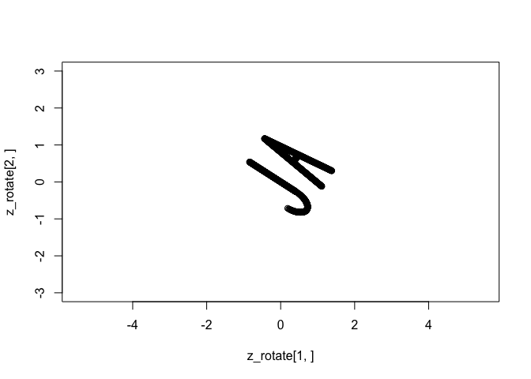

```r
z_rotate<-apply(z,2,function(x) leftMultiply(x,matrix(c(cos(1),-sin(1),sin(1),cos(1)),nrow=2,ncol=2)))
   plot(z_rotate[2,]~z_rotate[1,], xlim=c(-3,3), ylim=c(-3,3), col = 'black', asp = 1)
```

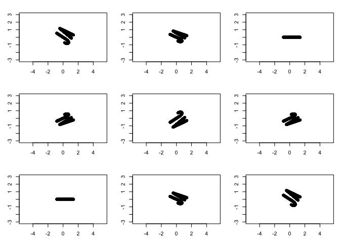

```r
par(mfrow = c(3,3), mar = c(3,3,2,1))
for (i in seq(0,2*pi,length.out=9)) {
  z_new <-rbind(z_rotate,rep(0,ncol(z)))
  z_reflect<-apply(z_new,2,function(x) leftMultiply(x,matrix(c(1,0,0,0,cos(i),-sin(i),0,sin(i),cos(i)),nrow=3,ncol=3)))
   plot(z_reflect[2,]~z_reflect[1,], xlim=c(-3,3), ylim=c(-3,3), col='black', asp = 1)
}
```

## Animating Transformations:

Use a loop to incrementally change the transformation matrix and visualize the effect on the shape over time.

The following code chunks generate GIF files of the aforementioned animations.

### Shearing Animation:

```r
saveGIF({
  for (i in seq(0,2,length.out=10)) {
    z_shear<-apply(z,2,function(x) leftMultiply(x,matrix(c(1,i,0,1),nrow=2,ncol=2)))
    plot(z_shear[2,]~z_shear[1,], xlim=c(-3,3), ylim=c(-3,3), col='black', asp = 1)
  }
}, movie.name = "shear_animation.gif", interval = 0.1)
```

```
## Output at: shear_animation.gif
```

```
## [1] TRUE
```

```r
#shear_gif <- image_read("/Users/jadamesng/Brooklyn College Dropbox/Julian Adames-Ng/MS Data Science/DATA 605/Homework 1/shear_animation.gif")
shear_gif <- image_read("shear_animation.gif")

#shear_gif
```

### Scaling Animation:

```r
saveGIF({
  for (i in seq(1,3,length.out=10)) {
    z_scale<-apply(z,2,function(x) leftMultiply(x,matrix(c(i,0,0,i),nrow=2,ncol=2)))
    plot(z_scale[2,]~z_scale[1,], xlim=c(-3,3), ylim=c(-3,3), col='black', asp = 1)
  }
}, movie.name = "scale_animation.gif", interval = 0.1)
```

```
## Output at: scale_animation.gif
```

```
## [1] TRUE
```

```r
#scale_gif <- image_read("/Users/jadamesng/Brooklyn College Dropbox/Julian Adames-Ng/MS Data Science/DATA 605/Homework 1/scale_animation.gif")
scale_gif <- image_read("scale_animation.gif")

#scale_gif
```

### Rotating Animation:

```r
saveGIF({
  for (i in seq(0,pi*2,length.out=20)) {
    z_rotate<-apply(z,2,function(x) leftMultiply(x,matrix(c(cos(i),-sin(i),sin(i),cos(i)),nrow=2,ncol=2)))
    plot(z_rotate[2,]~z_rotate[1,], xlim=c(-3,3), ylim=c(-3,3), col = 'black', asp = 1)
  }
}, movie.name = "rotation_animation.gif", interval = 0.1)
```

```
## Output at: rotation_animation.gif
```

```
## [1] TRUE
```

```r
#rotation_gif <- image_read("/Users/jadamesng/Brooklyn College Dropbox/Julian Adames-Ng/MS Data Science/DATA 605/Homework 1/rotation_animation.gif")
rotation_gif <- image_read("rotation_animation.gif")

#rotation_gif
```

### Reflecting Animation:

```r
saveGIF({
  for (i in seq(0,2*pi,length.out=20)) {
    z_new <-rbind(z_rotate,rep(0,ncol(z)))
    z_reflect<-apply(z_new,2,function(x) leftMultiply(x,matrix(c(1,0,0,0,cos(i),-sin(i),0,sin(i),cos(i)),nrow=3,ncol=3)))
    plot(z_reflect[2,]~z_reflect[1,], xlim=c(-3,3), ylim=c(-3,3), col='grey', asp = 1)
  }
}, movie.name = "ref_animation.gif", interval = 0.1)
```

```
## Output at: ref_animation.gif
```

```
## [1] TRUE
```

```r
#reflection_gif <- image_read("/Users/jadamesng/Brooklyn College Dropbox/Julian Adames-Ng/MS Data Science/DATA 605/Homework 1/ref_animation.gif")
reflection_gif <- image_read("ref_animation.gif")

#reflection_gif
```

# 2. Matrix Properties and Decomposition

## Context:

Every time you upload a photo to social media, algorithms often compress your image to reduce file size without significantly degrading quality. One of the key techniques used in this process is Singular Value Decomposition (SVD), which is another form of matrix factorization.

## Task:

Write an R function that performs Singular Value Decomposition (SVD) on a grayscale image (which can be represented as a matrix). Use this decomposition to compress the image by keeping only the top k singular values and their corresponding vectors. Demonstrate the effect of different values of k on the compressed image’s quality. You can choose any open-access grayscale image that is appropriate for a professional program.

## Instructions:

Convert a grayscale image into a matrix.

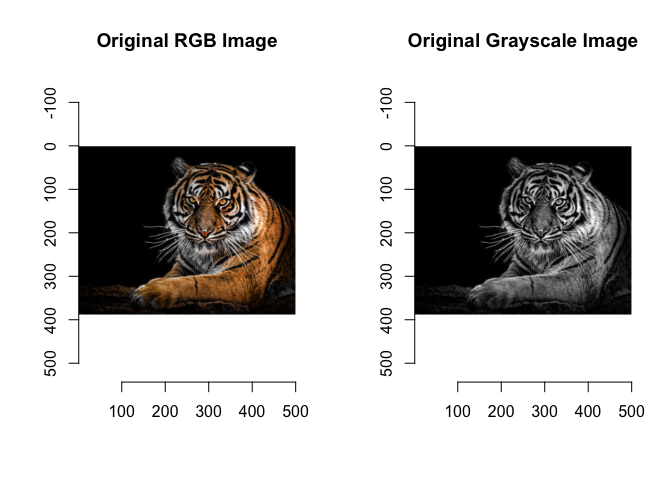

```r
rm(list = ls())

#t_image <- readJPEG("Tiger_Grayscale.jpg")
t_image <- load.image("tiger.jpeg")

t_gray <- grayscale(t_image)

par(mfrow = c(1, 2))

plot(t_image, main = "Original RGB Image")

plot(t_gray, main = "Original Grayscale Image")
```

```r
t_matrix <- as.matrix(t_gray)
```

Factorize the image matrix $A$ into $U \small\sum V^T$ using R’s built-in svd() function.

```r
t_svd <- svd(t_matrix)
```

Reconstruct the image using only the top k singular values and vectors.

```r
t_reconstructed <- function(k){
  U <- t_svd$u[, 1:k]
  D <- diag(t_svd$d[1:k])
  V <- t_svd$v[,1:k]
  return(U %*% D %*% t(V))
}

dim(t_matrix)
```

```
## [1] 500 388
```

Plot the original image alongside the compressed versions for various values of k (e.g., k = 5, 20, 50).

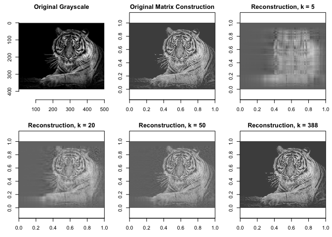

```r
t_plot <- function(ks){
  par(mfrow = c(2, 3), mar = c(3,3,2,1))
  plot(t_gray, main = "Original Grayscale")
  image(t_matrix[1:nrow(t_matrix), ncol(t_matrix):1], col = gray.colors(256), main = "Original Matrix Construction", asp = 0.776)
  for (k in ks){
    t_compressed <- t_reconstructed(k)
    image(t_compressed[1:nrow(t_compressed), ncol(t_compressed):1], col = gray.colors(256), main = paste("Reconstruction, k =", k), asp = 0.776)
  }
}

k_vals <- c(5, 20, 50, 388)

t_plot(k_vals)
```

# 3. Matrix Rank, Properties, and Eigenspace

## Determine the Rank of the Given Matrix:

Find the rank of the matrix $A$. Explain what the rank tells us about the linear independence of the rows and columns of matrix $A$. Identify if there are any linear dependencies among the rows or columns.

$$A = \begin{pmatrix}
2 & 4 & 1 & 3 \\
-2 & -3 & 4 & 1 \\
5 & 6 & 2 & 8 \\
-1 & -2 & 3 & 7
\end{pmatrix}$$

```r
A <- matrix(c(2,4,1,3,-2,-3,4,1,5,6,2,8,-1,-2,3,7), nrow = 4, byrow = TRUE)

A
```

```
##      [,1] [,2] [,3] [,4]
## [1,]    2    4    1    3
## [2,]   -2   -3    4    1
## [3,]    5    6    2    8
## [4,]   -1   -2    3    7
```

```r
rank_A <- qr(A)$rank

rank_A
```

```
## [1] 4
```

Here we see that the rank of matrix A is 4. This means that there are 4 linearly independent rows, which also means that there are 4 linearly independent columns. Thus, rank tells us the dimension of the row and column space. Since the rank is equal to the number of rows and the number of columns, then there are no linear dependencies among rows or columns. This means that no row can be expressed as a linear combination of the other rows and, likewise, no column can be expressed as a linear combination of the other columns.

## Matrix Rank Boundaries:

Given an $m \times n$ matrix where $m>n$, determine the maximum and minimum possible rank, assuming that the matrix is non-zero.

The maximum possible rank for such a matrix is $n$ since the rank cannot be larger than either the number of rows or columns and therefore must have a max value of the smaller value. The minimum possible rank would be 1 since this is a non-zero matrix.

## Rank and Row Reduction:

Determine the rank of matrix $B$. Perform a row reduction on matrix $B$ and describe how it helps in finding the rank. Discuss any special properties of matrix $B$ (e.g. is it a rank-deficient matrix?)

$$B = \begin{pmatrix}
2 & 5 & 7 \\
4 & 10 & 14 \\
1 & 2.5 & 3.5
\end{pmatrix}$$

The code below computes the rank of matrix $B$,
$$\mathrm{rank}(B) = 1$$
and performs a row reduction on matrix $B$. We will see that the row reduction simplifies the matrix $B$ down to
$$\text{RREF}(B) = \begin{pmatrix}
1 & 2.5 & 3.5 \\
0 & 0 & 0 \\
0 & 0 & 0
\end{pmatrix}$$
which shows one non-zero row. This non-zero row tells us that there is only one linearly independent row in the original matrix $B$. This verifies the rank of 1 that was computed.

```r
library(reticulate)
library(pracma)
#create the matrix
B <- matrix(c(2,5,7,4,10,14,1,2.5,3.5), nrow = 3, ncol = 3, byrow = TRUE)
B
```

```
##      [,1] [,2] [,3]
## [1,]    2  5.0  7.0
## [2,]    4 10.0 14.0
## [3,]    1  2.5  3.5
```

```r
#find the rank of matrix B
rank_B <- qr(B)$rank
cat(paste("\nThe rank of matrix B is:", rank_B, "\n\n"))
```

```
##
## The rank of matrix B is: 1
```

```r
#perform row reduction on matrix B
row_reduce_B <- rref(B)
row_reduce_B
```

```
##      [,1] [,2] [,3]
## [1,]    1  2.5  3.5
## [2,]    0  0.0  0.0
## [3,]    0  0.0  0.0
```

## Compute the Eigenvalues and Eigenvectors:

Find the eigenvalues and eigenvectors of the matrix $A$. Write out the characteristic polynomial and show your solution step by step. After finding the eigenvalues and eigenvectors, verify that the eigenvectors are linearly independent. If they are not, explain why.

$$A = \begin{pmatrix}
3 & 1 & 2 \\
0 & 5 & 4 \\
0 & 0 & 2
\end{pmatrix}$$

```r
A <- matrix(c(3,1,2,0,5,4,0,0,2), nrow = 3, byrow = TRUE)
A
```

```
##      [,1] [,2] [,3]
## [1,]    3    1    2
## [2,]    0    5    4
## [3,]    0    0    2
```

```r
eigens <- eigen(A)

e_vals_A <- eigens$values
e_vecs_A <- eigens$vectors

e_vals_A
```

```
## [1] 5 3 2
```

```r
e_vecs_A
```

```
##           [,1] [,2]       [,3]
## [1,] 0.4472136    1 -0.3713907
## [2,] 0.8944272    0 -0.7427814
## [3,] 0.0000000    0  0.5570860
```

### Results:

```r
#install.packages("polynom")
library(polynom)
char_poly <- polynomial(c(5, -1))*polynomial(c(3, -1))*polynomial(c(2, -1))
char_poly
```

```
## 30 - 31*x + 10*x^2 - x^3
```

### Results:

To determine if the eigenvectors are linearly independent, we can use row reduction on the matrix formed by these vectors.

```r
e_matrix_A <- cbind(e_vecs_A)

rref(e_matrix_A)
```

```
##      [,1] [,2] [,3]
## [1,]    1    0    0
## [2,]    0    1    0
## [3,]    0    0    1
```

```r
det(e_matrix_A)
```

```
## [1] -0.4982729
```

# 4. Project: Eigenfaces from the LFW (Labeled Faces in the Wild) Dataset

## Context:

Eigenfaces are a popular application of Principal Component Analysis (PCA) in computer vision. They are used for face recognition by finding the principal components (eigenvectors) of the covariance matrix of a set of facial images. These principal components represent the “eigenfaces” that can be combined to approximate any face in the dataset.

## Task:

Using the LFW (Labeled Faces in the Wild) dataset, build and visualize eigenfaces that account for 80% of the variability in the dataset. The LFW dataset is a well-known dataset containing thousands of labeled facial images, available for academic research.

## Instructions:

### 1. Download the LFW Dataset:

[output not shown]

### Setting up the Python Environment

```r
options(repos = c(CRAN = "https://cran.rstudio.com/"))
install.packages('reticulate')
py_install("scikit-learn")
```

```
## + /Users/jung/Library/r-miniconda/bin/conda install --yes --prefix /Users/jung/Library/r-miniconda/envs/r-reticulate -c conda-forge scikit-learn
```

```r
py_install("Pillow")
```

```
## + /Users/jung/Library/r-miniconda/bin/conda install --yes --prefix /Users/jung/Library/r-miniconda/envs/r-reticulate -c conda-forge Pillow
```

```r
py_install("matplotlib")
```

```
## + /Users/jung/Library/r-miniconda/bin/conda install --yes --prefix /Users/jung/Library/r-miniconda/envs/r-reticulate -c conda-forge matplotlib
```

```python
from sklearn.datasets import fetch_lfw_people
```

### 2. Preprocess the Images:

```python
import sklearn
from sklearn.datasets import fetch_lfw_people
import numpy as np
from PIL import Image
import matplotlib.pyplot as plt
from sklearn.decomposition import PCA

#Download the LFW dataset (resized to smaller size for computational efficiency)
lfw_people = fetch_lfw_people(min_faces_per_person=70, resize=1)

#Get the image data and target labels
#2D array: each face image
images = lfw_people.images
#Height and width of images
h, w = lfw_people.images.shape[1], lfw_people.images.shape[2]

#Convert to grayscale and resize to 64x64
grayscale_images = []
for img in images:
    #Normalize the pixel values to range [0, 255] and convert to uint8
    img = (img - img.min()) / (img.max() - img.min()) * 255
    img = img.astype(np.uint8)

    #Convert NumPy array to PIL Image
    pil_img = Image.fromarray(img)
    #Convert to grayscale ('L' mode)
    pil_img = pil_img.convert('L')
    #Resize to 64x64
    pil_img = pil_img.resize((64, 64), Image.Resampling.LANCZOS)
    #Convert back to NumPy array
    grayscale_images.append(np.array(pil_img))

#Convert the list of images into a NumPy array
grayscale_images = np.array(grayscale_images)

#Flatten each image into a vector
n_samples, h_new, w_new = grayscale_images.shape
flat_images = grayscale_images.reshape((n_samples, h_new * w_new))

#Print the shape of the flattened images (each row is a flattened 64x64 image)
print(f"Shape of the flattened image data: {flat_images.shape}")
```

```
## Shape of the flattened image data: (1288, 4096)
```

```python
#Visualize some of the grayscale, resized images
fig, axes = plt.subplots(2, 5, figsize=(15, 5))
for i, ax in enumerate(axes.flat):
    ax.imshow(grayscale_images[i], cmap='gray')
    ax.set(xticks=[], yticks=[])
```

[output not shown]

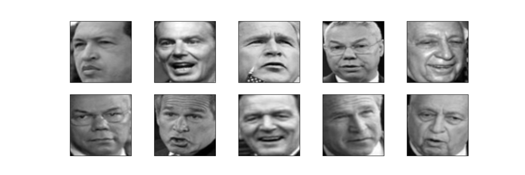

```python
plt.show()
```

### Apply PCA:

```python
#Apply PCA on the flattened images
#Set the number of components (e.g., enough components to explain 80% of the variance)
pca = PCA(n_components=0.80, whiten=True)  # 80% of variance
pca.fit(flat_images)
```

```
## PCA(n_components=0.8, whiten=True)
```

```python
#Transform the images into the PCA space
pca_images = pca.transform(flat_images)

#Retrieve the eigenfaces (principal components)
eigenfaces = pca.components_.reshape((-1, h_new, w_new))

#Print information about the PCA result
print(f"Original shape: {flat_images.shape}")
```

```
## Original shape: (1288, 4096)
```

```python
print(f"Reduced shape after PCA: {pca_images.shape}")
```

```
## Reduced shape after PCA: (1288, 42)
```

```python
print(f"Number of eigenfaces: {eigenfaces.shape[0]}")
```

```
## Number of eigenfaces: 42
```

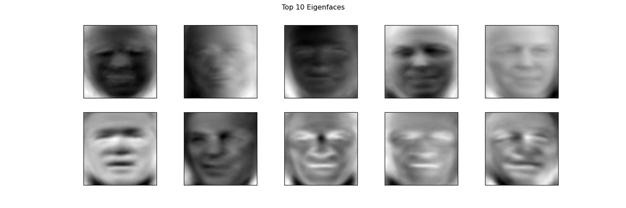

```python
#Visualize some eigenfaces
fig, axes = plt.subplots(2, 5, figsize=(15, 5), subplot_kw={'xticks':[], 'yticks':[]})
for i, ax in enumerate(axes.flat):
    ax.imshow(eigenfaces[i], cmap='gray')
plt.suptitle('Top 10 Eigenfaces')
plt.show()
```

### 4. Visualize Eigenfaces:

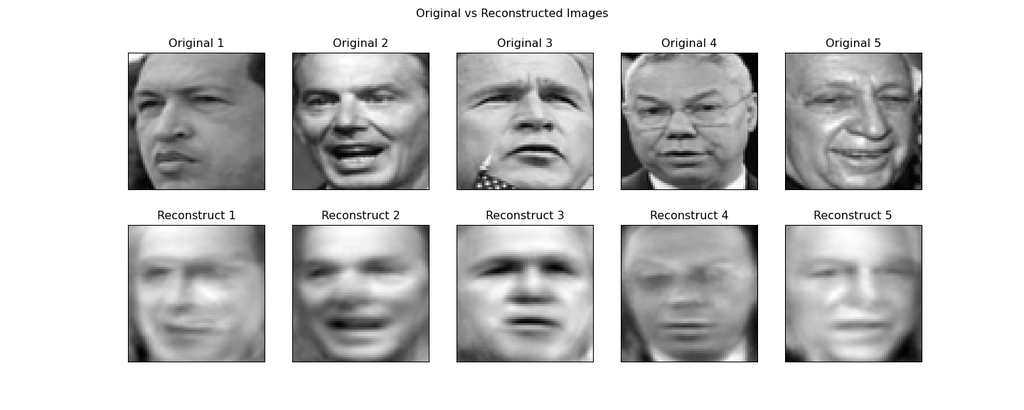

```python
#Reconstruct some original images using the top eigenfaces
#Reconstruct the images from their PCA projection (approximation)
#Project back into original space
reconstructed_images = pca.inverse_transform(pca_images)
reconstructed_images = reconstructed_images.reshape((n_samples, h_new, w_new))

#Compare original images with reconstructed images
#Number of images to show for comparison
n_images_to_show = 5
fig, axes = plt.subplots(2, n_images_to_show, figsize=(15, 6), subplot_kw={'xticks':[], 'yticks':[]})

for i in range(n_images_to_show):
    #Show original image
    axes[0, i].imshow(grayscale_images[i], cmap='gray')
    axes[0, i].set_title(f"Original {i+1}")

    #Show reconstructed image
    axes[1, i].imshow(reconstructed_images[i], cmap='gray')
    axes[1, i].set_title(f"Reconstruct {i+1}")

plt.suptitle('Original vs Reconstructed Images')
plt.show()
```

### Results:

The original images are crisp and clear, showcasing a high level of detail in each face, allowing for easy recognition of the individuals. In contrast,the reconstructed images obtained through Principal Component Analysis (PCA) appear somewhat blurry, making it difficult to identify the individuals with certainty. However, they still retain some vague yet identifiable features. This is the essence of PCA. By reducing the dimensionality, it retains significant features from high-dimensional datasets in a lower-dimensional context. This not only decreases computational complexity, potentially reducing rendering times, but also makes it easier to interpret the data by minimizing ‘noise’ that may obscure recognizable patterns.